# Portfolio Visualization Examples in R

Below are a few visualization examples I’ve made using R. All of them utilize Tidyverse, specifically ggplot2 although I did use lubridate in example 3. They should all be color-blind friendly, but if you have difficulty seeing them nonetheless, or if you have any other questions, please feel free to contact me at my email, available on [my portfolio website](https://janecasto.com). Enjoy! -Jane

### Example 1: Palmer Penguins

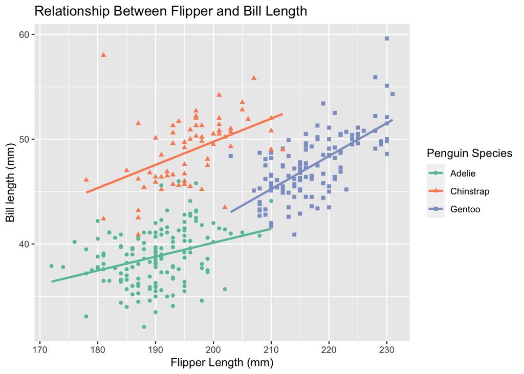

The most iconic data set example is of course the Palmer Penguins data. The data set is available for download [here](https://allisonhorst.github.io/palmerpenguins/). This visualization shows the relationship between the flipper length and bill length in millimeters of the three different penguin species, broken down by color and shape. The color palette is color-blind friendly, courtesy of [Color Brewer 2](https://colorbrewer2.org/#type=qualitative&scheme=Set2&n=3). The palette used is Set2.

### Example 2: Mice Treatments

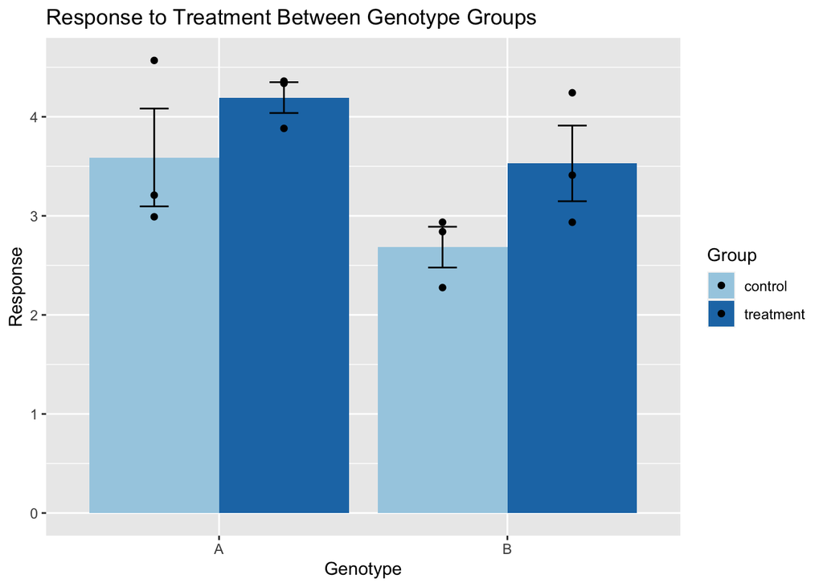

This data is an example set provided by the [UC Davis Data Lab](https://datalab.ucdavis.edu/). The plot we’ve created from this data shows the mean difference in response between the control and treatment groups of mice, grouped by genotype. The chart includes error bars in the center of each group. Once again, the colors are provided by [Color Brewer 2](https://colorbrewer2.org/#type=qualitative&scheme=Set2&n=3), but this time the Paired palette was used.

### Example 3: Flu Rates

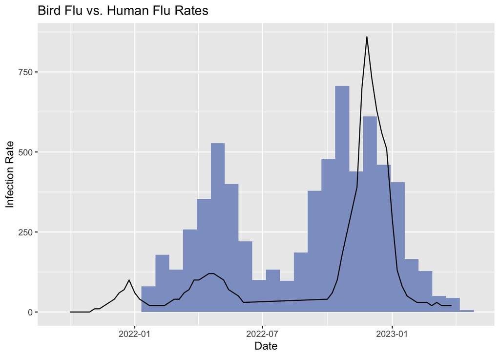

The last example here has data also provided by the [UC Davis Data Lab](https://datalab.ucdavis.edu/) as well, and particularly uses data that tracks flu infection rates, found at [this link](https://ucdavis.app.box.com/s/a4m4ermwm0lqes2sh1jckdf16h0rpdkc), and bird flu infection rates, which can be found [here](https://ucdavis.app.box.com/s/babz1b5ak0kh7q7cktg7k5gzrt2ve9gc). The two are visualized together here to see if they spike at the same time. The purple histogram showcases the bird flu infections, and the black line shows the infection rates for humans. As we can see, during this time period, both flu rates had a spike at a similar time. We can infer there may be a correlation between human flu rates and bird flu rates.

#### Thank you for checking out these examples!

##### If you would like to return to the portfolio website, please click [here](https://janecasto.com).